# EVS Data Analysis by Country

Kangrui Liu

2025-03-25

# Introduction

This report explores the 2017 European Values Study (EVS) for RS, focusing on two variables measuring attitudes toward gender roles (v72) and immigration (v80). The analysis includes descriptive statistics, visualization of how these attitudes change with age, and regression modeling incorporating age, age squared, sex, and education.

# Data Preparation

```r
load("data/evs_clean.RData")

evs_country <- evs_clean %>%
  filter(country == params$country)
```

# Descriptive Statistics

## Continuous Variables

```r
evs_country %>%
  dplyr::select(age, v72, v80) %>%
  summary()
```

```
##       age             v72            v80
##  Min.   : 0.00   Min.   :1.00   Min.   :1.00
##  1st Qu.:18.00   1st Qu.:2.00   1st Qu.:1.00
##  Median :19.00   Median :3.00   Median :2.00
##  Mean   :20.42   Mean   :2.52   Mean   :1.93
##  3rd Qu.:24.00   3rd Qu.:3.00   3rd Qu.:3.00
##  Max.   :46.00   Max.   :4.00   Max.   :5.00
```

## Categorical Variables

```r
evs_country %>%
  count(sex) %>%
  kable(caption = "Frequency Table for Sex")
```

Frequency Table for Sex

| sex | n |
| --- | --- |
| 1 | 611 |
| 2 | 715 |

```r
evs_country %>%
  count(education) %>%
  kable(caption = "Frequency Table for Education")
```

Frequency Table for Education

| education | n |
| --- | --- |
| 1 | 216 |
| 2 | 690 |
| 3 | 420 |

# Visualizations

## v72 by Age

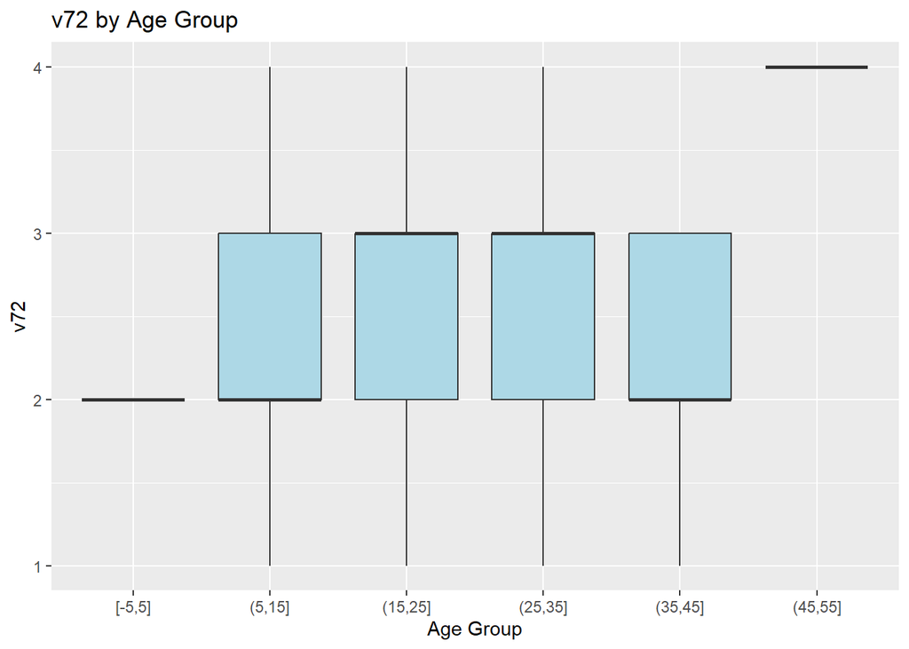

```r
ggplot(evs_country, aes(x = cut_width(age, width=10), y = v72)) +
  geom_boxplot(fill = "lightblue") +
  labs(title = "v72 by Age Group", x = "Age Group", y = "v72")
```

## v80 by Age

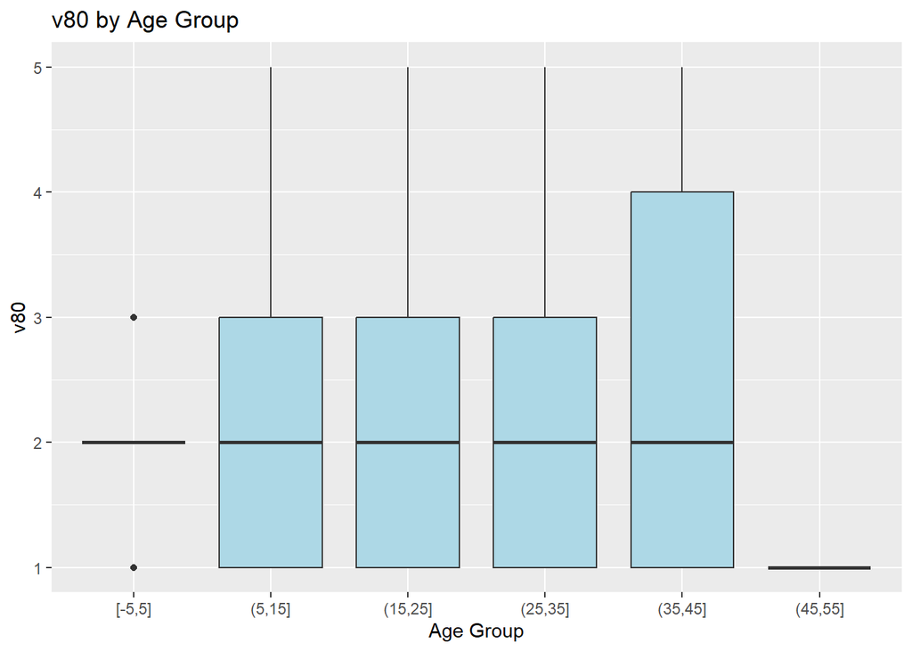

```r
ggplot(evs_country, aes(x = cut_width(age, width=10), y = v80)) +
  geom_boxplot(fill = "lightblue") +
  labs(title = "v80 by Age Group", x = "Age Group", y = "v80")
```

# Regression Analysis

```r
mod1 <- lm(v72 ~ age + age_sq + sex + education, data = evs_country)
mod2 <- lm(v80 ~ age + age_sq + sex + education, data = evs_country)

screenreg(list("v72" = mod1, "v80" = mod2))
```

```
##
## =====================================
##              v72          v80
## -------------------------------------
## (Intercept)     1.41 ***     2.02 ***
##                (0.26)       (0.32)
## age             0.05 *      -0.03
##                (0.02)       (0.03)
## age_sq         -0.00         0.00
##                (0.00)       (0.00)
## sex             0.12 *       0.06
##                (0.05)       (0.06)
## education       0.08         0.12
##                (0.05)       (0.07)
## -------------------------------------
## R^2             0.04         0.00
## Adj. R^2        0.04         0.00
## Num. obs.    1326         1326
## =====================================
## *** p < 0.001; ** p < 0.01; * p < 0.05
```

# Dynamic Interpretation

In RS, the regression results show that sex has a positive relationship with attitudes towards gender roles (v72) (Coefficient = 0.12; p-value = 0.013). For attitudes towards immigration (v80), sex shows a positive relationship (Coefficient = 0.06; p-value = 0.31).

# Summary

This report provides a detailed overview of attitudes towards gender roles and immigration in RS, highlighting key demographic insights, visualizing how these attitudes vary by age, and exploring their statistical relationships with demographic predictors.